# PART 1️⃣ — Data Inspection & Understanding

## 1️⃣ Data Inspection Task

### Load the dataset

```python
# 1: Data Handling & Inspection

import pandas as pd

import numpy as np

# 2: Visualization

import matplotlib.pyplot as plt



import seaborn as sns

# 3. Data Splitting & Leakage Prevention

from sklearn.model_selection import train_test_split

# 4: Encoding & Scaling (Preprocessing)


from sklearn.preprocessing import OneHotEncoder, OrdinalEncoder, RobustScaler

# 5: Pipeline Construction



from sklearn.compose import ColumnTransformer

from sklearn.pipeline import Pipeline




# Accuracy و F1-Score مقارنة النتائج
from sklearn.metrics import accuracy_score, f1_score, classification_report, confusion_matrix


from sklearn.model_selection import cross_val_score


from sklearn.model_selection import GridSearchCV


%matplotlib inline

import warnings


warnings.filterwarnings('ignore')

sns.set(style="whitegrid") # لتوحيد شكل الرسومات في البروجكت كله
```

```python
df = pd.read_csv('Heart_disease.csv')
df.head()
```

|  | HeartDisease | BMI | Smoking | AlcoholDrinking | Stroke | PhysicalHealth | MentalHealth | DiffWalking | Sex | AgeCategory | Race | Diabetic | PhysicalActivity | GenHealth | SleepTime | Asthma | KidneyDisease | SkinCancer |
| --- | --- | --- | --- | --- | --- | --- | --- | --- | --- | --- | --- | --- | --- | --- | --- | --- | --- | --- |
| 0 | No | 16.60 | Yes | No | No | 3 | 30 | No | Female | 55-59 | White | Yes | Yes | Very good | 5.0 | Yes | No | Yes |
| 1 | No | 20.34 | No | No | Yes | 0 | 0 | No | Female | 80 or older | White | No | Yes | Very good | 7.0 | No | No | NaN |
| 2 | No | NaN | Yes | No | No | 20 | 30 | No | Male | 65-69 | White | Yes | Yes | Fair | 8.0 | Yes | No | No |
| 3 | No | 24.21 | No | No | No | 0 | 0 | No | Female | 75-79 | White | No | No | Good | 6.0 | No | No | Yes |
| 4 | No | 23.71 | No | No | No | 28 | 0 | Yes | Female | 40-44 | White | No | Yes | Very good | 8.0 | No | No | No |

### Identify:

o Missing values  
o Data types  
o Categorical vs numerical features

### هنستكشف الداتا بتاعتنا قبل ما نعمل اي بروسيس

### 1: Data exploring

```python
df.shape
```

```
(16859, 18)
```

```python
df.info()
```

```
<class 'pandas.core.frame.DataFrame'>
RangeIndex: 16859 entries, 0 to 16858
Data columns (total 18 columns):
 #   Column            Non-Null Count  Dtype
---  ------            --------------  -----
 0   HeartDisease      16859 non-null  object
 1   BMI               15255 non-null  float64
 2   Smoking           16859 non-null  object
 3   AlcoholDrinking   16859 non-null  object
 4   Stroke            16859 non-null  object
 5   PhysicalHealth    16859 non-null  int64
 6   MentalHealth      16859 non-null  int64
 7   DiffWalking       16854 non-null  object
 8   Sex               16859 non-null  object
 9   AgeCategory       16859 non-null  object
 10  Race              16859 non-null  object
 11  Diabetic          16859 non-null  object
 12  PhysicalActivity  16859 non-null  object
 13  GenHealth         16859 non-null  object
 14  SleepTime         16355 non-null  float64
 15  Asthma            16859 non-null  object
 16  KidneyDisease     16859 non-null  object
 17  SkinCancer        15695 non-null  object
dtypes: float64(2), int64(2), object(14)
memory usage: 2.3+ MB
```

```python
df.isna().sum()
```

```
HeartDisease           0
BMI                 1604
Smoking                0
AlcoholDrinking        0
Stroke                 0
PhysicalHealth         0
MentalHealth           0
DiffWalking            5
Sex                    0
AgeCategory            0
Race                   0
Diabetic               0
PhysicalActivity       0
GenHealth              0
SleepTime            504
Asthma                 0
KidneyDisease          0
SkinCancer          1164
dtype: int64
```

### هنشيل الصفوف المتكرره

```python
#نعرف عدد الصفوف  المتكرره عشان نتخلص منها

print(f"Duplicates before: {df.duplicated().sum()}")
```

```
Duplicates before: 121
```

```python
# هنا هيشيل كل الصفوف المتكرره
df.drop_duplicates(inplace=True)


print(f"Duplicates after: {df.duplicated().sum()}")
```

```
Duplicates after: 0
```

```python
df.shape
# هنا احنا شلنا كل الصفوف المتكرره لو الداتا كبيره كان هيكون الفرق كبير لاحظ من 16859 بقيت 16738
```

```
(16738, 18)
```

```python
for col in ['BMI', 'PhysicalHealth', 'MentalHealth', 'SleepTime']:
    print(col, len(df[col].dropna().unique()), df[col].dropna().unique())
```

```
BMI 1726 [16.6  20.34 24.21 ... 19.59 24.64 40.43]
PhysicalHealth 31 [ 3  0 20 28  6 15  5 30  7  1  2 21  4 10 14 18  8 25 16 29 27 17 24 12
 23 26 22 19  9 13 11]
MentalHealth 29 [30  0  2  5 15  8  4  3 10 14 20  1  7 24  9 28 16 12  6 25 17 18 21 29
 22 13 23 27 26]
SleepTime 20 [ 5.  7.  8.  6. 12.  4. 10. 15.  9.  3.  2.  1. 16. 18. 14. 20. 11. 13.
 17. 24.]
```

#### **Ordinal categorical Features:**

O **PhysicalHealth** (0, 1–5, 6–15, 16–30)  
O **MentalHealth** (0, 1–3, 4–7, 8–14, 15–21, 22–30)  
O **SleepTime** (≤5, 6–7, 8, 9–10, ≥11)

#### **Look categorical but contain ordering:**

O **AgeCategory**

### Why misclassifying a feature is dangerous

- Adds **false mathematical assumptions**
- Destroys **ordinal ordering**
- Distorts **model learning**
  - Linear models → wrong coefficients
  - Distance models → bad distances
  - Tree models → poor splits
- Produces **misleading interpretations**

**Rule:**

> Classify features by **meaning**, not appearance.

# PART 2️⃣ — Visualization & Insights

### في الجزء دا هنستكشف الداتا علي شكل روسومات عشان نعرف شكل التوزيعه والقيم الشاذه ودا هيساعدنا علي اتخاذ القرار عشان نعرف نتعامل مع القيم المفقوده ونعالجها

```python
#هنا هنعمل رسمه التارجت عشان نعرف هل الداتا متوازنه ولا لا
#plt.figure(figsize=(6, 4))

#sns.countplot(x='HeartDisease', data=df) # هنا target --> herat disease :)


# هنا عشان علي كل axis يكون ليه عنوان عشان يوضح ويبسط الدنا اكتر مش حاجه اساسيه في الكود
#plt.title(' Target : Heart Disease  ')

#plt.xlabel('Has Heart Disease?')

#plt.ylabel('Count')

#plt.title('Target: Heart Disease ')
```

[figure not shown]

```python
# هو هو نفس كود التارجت بس هنا في حاجات زياده عشان الشكل يكون اوضح
plt.figure(figsize=(7, 5))


sns.set_palette("pastel")

ax = sns.countplot(x='HeartDisease', data=df)


plt.title(' Target : Heart Disease  ')

plt.xlabel('Has Heart Disease?')


plt.ylabel('Count')


total = len(df)
for p in ax.patches:
    percentage = f'{100 * p.get_height() / total:.1f}%'

    ax.annotate(percentage, (p.get_x() + p.get_width() / 2., p.get_height()),

                ha='center', va='center', xytext=(0, 10), textcoords='offset points')

plt.show()
```

### هنلاحظ في الرسمه الي فوق ان الداتا مش متوازنة بنسبة 100% وكدا ال accurcy مش مظبوطه

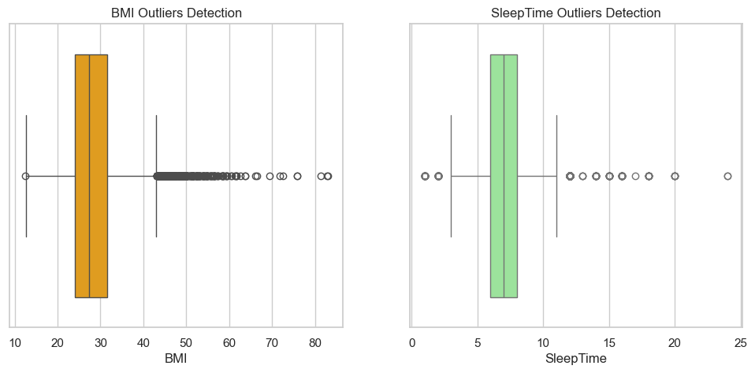

```python
# هنا رسمة ال botplox عشان نشوف ال outlairs
plt.figure(figsize=(12, 5))

# رسم  bmi
plt.subplot(1, 2, 1)



sns.boxplot(x=df['BMI'], color='orange')

plt.title('BMI Outliers Detection')

# رسم الـ SleepTime
plt.subplot(1, 2, 2)

sns.boxplot(x=df['SleepTime'], color='lightgreen')

plt.title('SleepTime Outliers Detection')

plt.show()
```

### من خلال الرسمه هتلاحظ انه فيه outlaires كتير فا ال best decision هيكون ال median لانه يملئ القيم المفقوده ويقدر يتعامل مع القيم الشاذه ويمنع تغيير توزيع الداتا

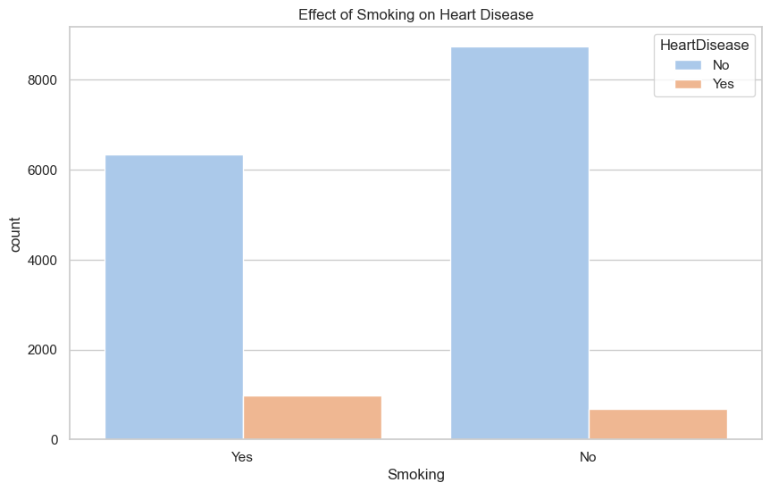

```python
# هل التدخين فعلاً مرتبط بمرض القلب؟

plt.figure(figsize=(10, 6))

sns.countplot(x='Smoking', hue='HeartDisease', data=df)


plt.title('Effect of Smoking on Heart Disease')

plt.show()
```

```python
import pandas as pd
import matplotlib.pyplot as plt

data = pd.read_csv('Heart_disease.csv')

print("Loaded successfully")
print(data.shape)
```

```
Loaded successfully
(16859, 18)
```

## 3) Target Variable Visualization

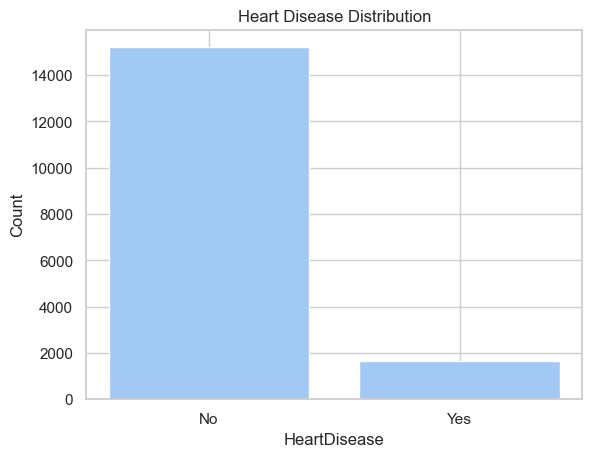

```
Class Distribution:
HeartDisease
No     15205
Yes     1654
Name: count, dtype: int64

Percentage Distribution:
HeartDisease
No     90.189216
Yes     9.810784
Name: count, dtype: float64
```

```python
# Using Bar Chart (Countplot equivalent)

target_counts = data['HeartDisease'].value_counts()

plt.figure()
plt.bar(target_counts.index, target_counts.values)
plt.title("Heart Disease Distribution")
plt.xlabel("HeartDisease")
plt.ylabel("Count")
plt.show()

print("Class Distribution:")
print(target_counts)

print("\nPercentage Distribution:")
print((target_counts / len(data)) * 100)
```

### Target Analysis

Feature Type: Binary Categorical  
Chosen Visualization: Bar Chart

**Insight:**

- The dataset is highly imbalanced.
- HeartDisease = Yes represents approximately 10% of the dataset,
- while No represents around 90%.

**Impact:**

- Accuracy is not a reliable metric.
- Recall and F1-score are more appropriate.
- Stratified splitting is required.

## 4) Numerical Feature Distribution

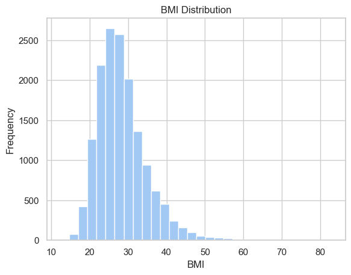

```
Summary Statistics for BMI:
count    15255.000000
mean        28.380571
std          6.410818
min         12.400000
25%         23.990000
50%         27.390000
75%         31.620000
max         83.000000
Name: BMI, dtype: float64
```

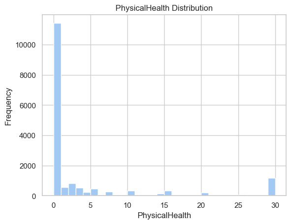

```
Summary Statistics for PhysicalHealth:
count    16859.000000
mean         3.840085
std          8.382590
min          0.000000
25%          0.000000
50%          0.000000
75%          2.000000
max         30.000000
Name: PhysicalHealth, dtype: float64
```

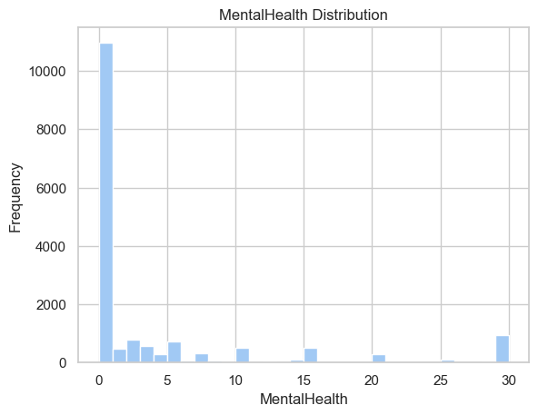

```
Summary Statistics for MentalHealth:
count    16859.000000
mean         3.867015
std          7.962250
min          0.000000
25%          0.000000
50%          0.000000
75%          3.000000
max         30.000000
Name: MentalHealth, dtype: float64
```

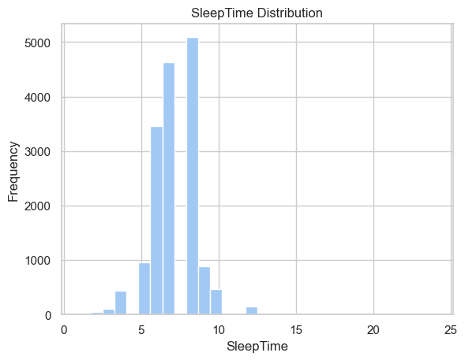

```
Summary Statistics for SleepTime:
count    16355.000000
mean         7.138490
std          1.519619
min          1.000000
25%          6.000000
50%          7.000000
75%          8.000000
max         24.000000
Name: SleepTime, dtype: float64
```

```python
# Using Histogram

numerical_features = ['BMI', 'PhysicalHealth', 'MentalHealth', 'SleepTime']

for feature in numerical_features:

    plt.figure()
    plt.hist(data[feature], bins=30)
    plt.title(f"{feature} Distribution")
    plt.xlabel(feature)
    plt.ylabel("Frequency")
    plt.show()

    print(f"\nSummary Statistics for {feature}:")
    print(data[feature].describe())
```

### BMI

Feature Type: Continuous Numerical Observation:

- Right-skewed distribution
- Extreme outliers (max = 83)
- Outliers present Conclusion: Robust scaling may be required.

### PhysicalHealth

Feature Type: Discrete Numerical Observation:

- Highly right-skewed
- Majority values are 0
- Long tail up to 30 Conclusion: Strong skewness → RobustScaler preferred.

### MentalHealth

Feature Type: Discrete Numerical Observation:

- Similar to PhysicalHealth
- Many zeros
- Long right tail Conclusion: RobustScaler recommended.

### SleepTime

Feature Type: Continuous Numerical Observation:

- Slight skewness
- Most values between 6–8 hours
- Some extreme values (up to 24) Conclusion: Mild outliers; StandardScaler acceptable, Robust safer.

## 5) Categorical Feature Distribution

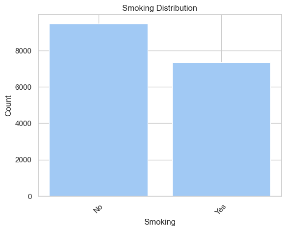

```
Distribution for Smoking:
Smoking
No     9496
Yes    7363
Name: count, dtype: int64

Percentage:
Smoking
No     56.325998
Yes    43.674002
Name: count, dtype: float64
```

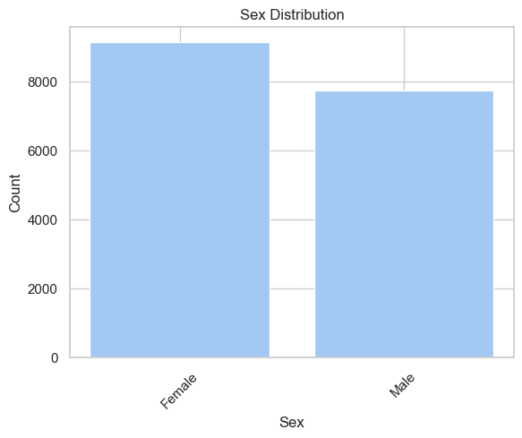

```
Distribution for Sex:
Sex
Female    9122
Male      7737
Name: count, dtype: int64

Percentage:
Sex
Female    54.107598
Male      45.892402
Name: count, dtype: float64
```

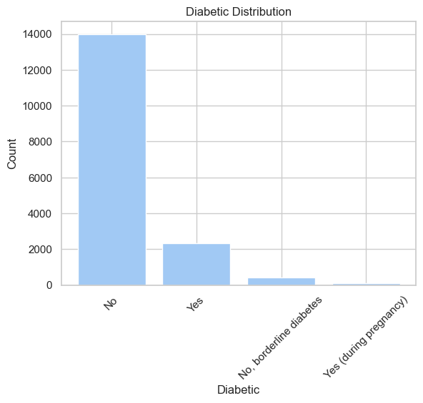

```
Distribution for Diabetic:
Diabetic
No                         14002
Yes                         2338
No, borderline diabetes      403
Yes (during pregnancy)       116
Name: count, dtype: int64

Percentage:
Diabetic
No                         83.053562
Yes                        13.867964
No, borderline diabetes     2.390415
Yes (during pregnancy)      0.688060
Name: count, dtype: float64
```

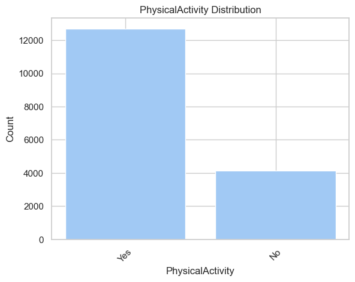

```
Distribution for PhysicalActivity:
PhysicalActivity
Yes    12705
No      4154
Name: count, dtype: int64

Percentage:
PhysicalActivity
Yes    75.360342
No     24.639658
Name: count, dtype: float64
```

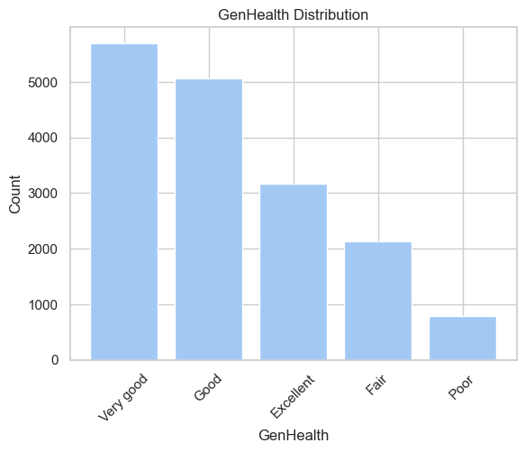

```
Distribution for GenHealth:
GenHealth
Very good    5699
Good         5063
Excellent    3174
Fair         2140
Poor          783
Name: count, dtype: int64

Percentage:
GenHealth
Very good    33.803903
Good         30.031437
Excellent    18.826739
Fair         12.693517
Poor          4.644404
Name: count, dtype: float64
```

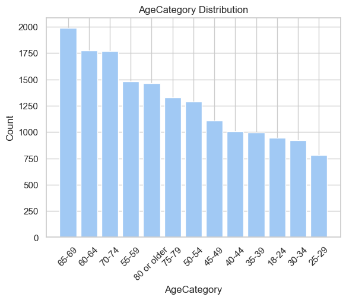

```
Distribution for AgeCategory:
AgeCategory
65-69          1987
60-64          1774
70-74          1769
55-59          1483
80 or older    1467
75-79          1331
50-54          1287
45-49          1108
40-44          1008
35-39           995
18-24           944
30-34           924
25-29           782
Name: count, dtype: int64

Percentage:
AgeCategory
65-69          11.785990
60-64          10.522570
70-74          10.492912
55-59           8.796489
80 or older     8.701584
75-79           7.894893
50-54           7.633905
45-49           6.572157
40-44           5.979002
35-39           5.901892
18-24           5.599383
30-34           5.480752
25-29           4.638472
Name: count, dtype: float64
```

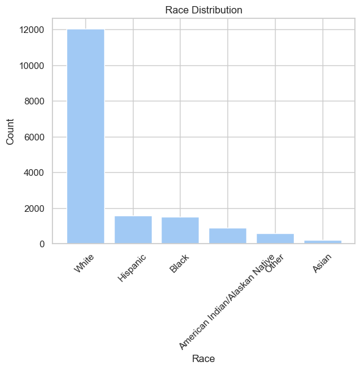

```
Distribution for Race:
Race
White                             12034
Hispanic                           1576
Black                              1515
American Indian/Alaskan Native      913
Other                               603
Asian                               218
Name: count, dtype: int64

Percentage:
Race
White                             71.380272
Hispanic                           9.348123
Black                              8.986298
American Indian/Alaskan Native     5.415505
Other                              3.576725
Asian                              1.293078
Name: count, dtype: float64
```

```python
# Using Bar Chart

categorical_features = [
    'Smoking', 'Sex', 'Diabetic',
    'PhysicalActivity', 'GenHealth',
    'AgeCategory', 'Race'
]

for feature in categorical_features:

    counts = data[feature].value_counts()

    plt.figure()
    plt.bar(counts.index.astype(str), counts.values)
    plt.title(f"{feature} Distribution")
    plt.xlabel(feature)
    plt.ylabel("Count")
    plt.xticks(rotation=45)
    plt.show()

    print(f"\nDistribution for {feature}:")
    print(counts)

    print("\nPercentage:")
    print((counts / len(data)) * 100)
```

**Smoking:**

- Binary feature.
- Distribution relatively balanced.

**Sex:**

- Binary feature.
- Nearly balanced.

**Diabetic:**

- Nominal categorical with 4 categories.
- Strong internal imbalance (majority = No).

**PhysicalActivity:**

- Binary.
- Imbalanced toward Yes.

**GenHealth:**

- Ordinal categorical.
- Most responses are Very good and Good.

**AgeCategory:**

- Ordinal categorical.
- Older age groups dominate.

**Race:**

- Nominal categorical.
- Highly imbalanced (White ≈ 71%).

## 6) Feature vs Target Analysis (CRITICAL)

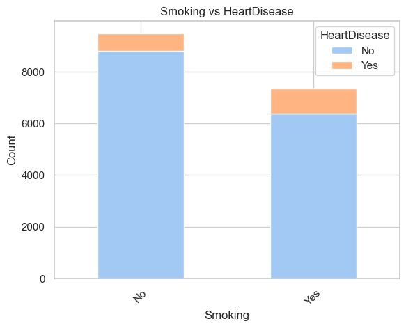

```
Percentage Distribution for Smoking:
HeartDisease         No        Yes
Smoking
No            92.933867   7.066133
Yes           86.649464  13.350536
```

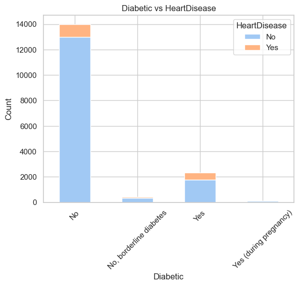

```
Percentage Distribution for Diabetic:
HeartDisease                    No        Yes
Diabetic
No                       92.729610   7.270390
No, borderline diabetes  87.841191  12.158809
Yes                      74.978614  25.021386
Yes (during pregnancy)   98.275862   1.724138
```

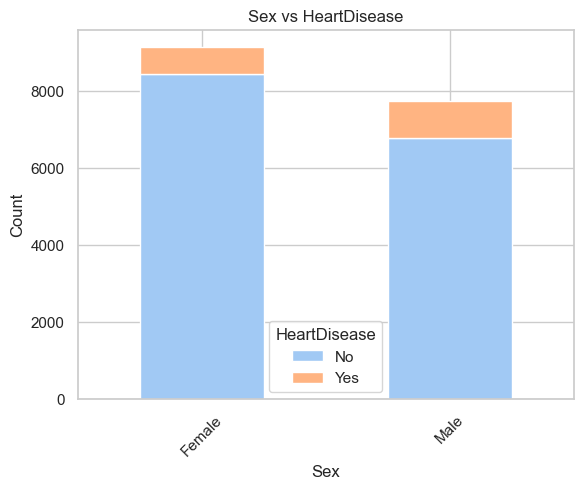

```
Percentage Distribution for Sex:
HeartDisease         No        Yes
Sex
Female        92.326244   7.673756
Male          87.669639  12.330361
```

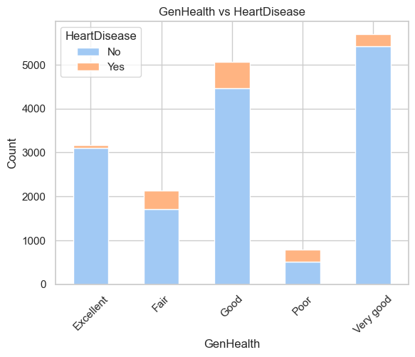

```
Percentage Distribution for GenHealth:
HeartDisease         No        Yes
GenHealth
Excellent     97.794581   2.205419
Fair          79.626168  20.373832
Good          88.149319  11.850681
Poor          65.134100  34.865900
Very good     95.174592   4.825408
```

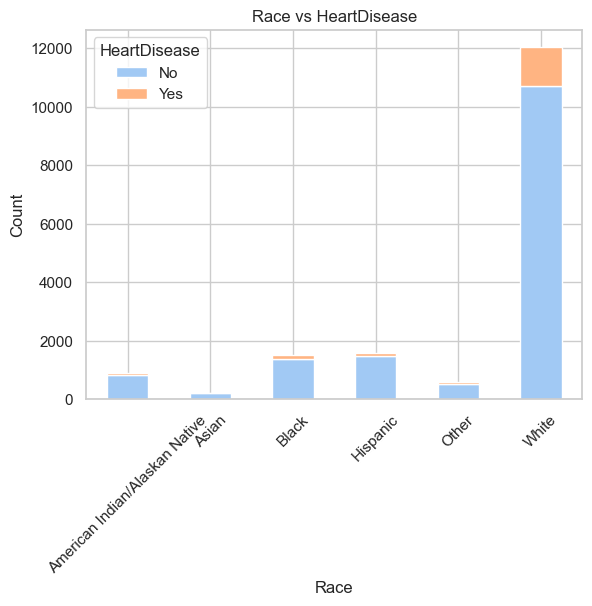

```
Percentage Distribution for Race:
HeartDisease                           No        Yes
Race
American Indian/Alaskan Native  92.332968   7.667032
Asian                           97.247706   2.752294
Black                           91.485149   8.514851
Hispanic                        94.670051   5.329949
Other                           89.552239  10.447761
White                           89.180655  10.819345
```

```python
# Categorical vs Target
# Using Stacked Bar Chart

categorical_vs_target = ['Smoking', 'Diabetic', 'Sex', 'GenHealth', 'Race']

for feature in categorical_vs_target:

    cross_tab = pd.crosstab(data[feature], data['HeartDisease'])

    cross_tab.plot(kind='bar', stacked=True)
    plt.title(f"{feature} vs HeartDisease")
    plt.xlabel(feature)
    plt.ylabel("Count")
    plt.xticks(rotation=45)
    plt.show()

    print(f"\nPercentage Distribution for {feature}:")
    print(pd.crosstab(data[feature], data['HeartDisease'], normalize='index') * 100)
```

**Smoking:**

- Smokers show a higher percentage of HeartDisease.
- Strong predictive candidate.

**Diabetic:**

- Diabetic = Yes shows significantly higher HeartDisease ratio.
- Strong predictive candidate.

**Sex:**

- Males show higher HeartDisease ratio.
- Medium importance.

**GenHealth:**

- Poor and Fair health categories show very high HeartDisease ratios.
- Strong predictive candidate.

**Race:**

- Distribution relatively similar across target.
- Weak predictive signal.

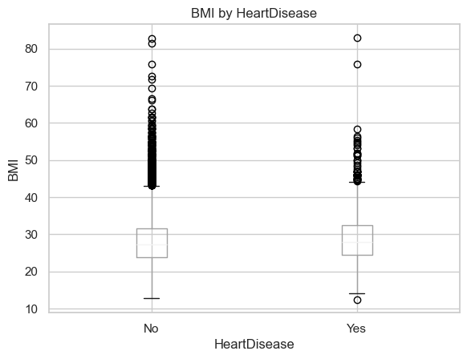

```
Median of BMI by HeartDisease:
HeartDisease
No     27.34
Yes    27.98
Name: BMI, dtype: float64
```

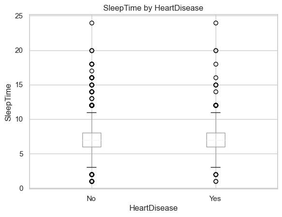

```
Median of SleepTime by HeartDisease:
HeartDisease
No     7.0
Yes    7.0
Name: SleepTime, dtype: float64
```

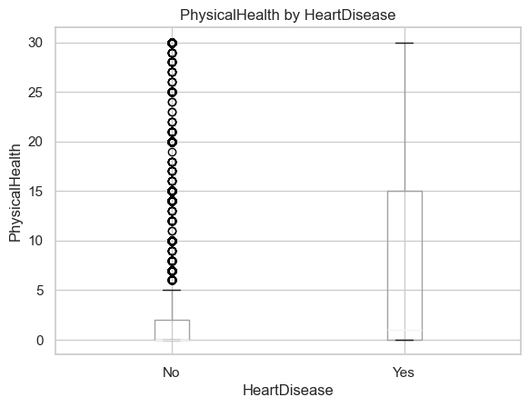

```
Median of PhysicalHealth by HeartDisease:
HeartDisease
No     0.0
Yes    1.0
Name: PhysicalHealth, dtype: float64
```

```python
# Numerical vs Target
# Using Boxplot by Target

numerical_vs_target = ['BMI', 'SleepTime', 'PhysicalHealth']

for feature in numerical_vs_target:

    plt.figure()
    data.boxplot(column=feature, by='HeartDisease')
    plt.title(f"{feature} by HeartDisease")
    plt.suptitle("")
    plt.xlabel("HeartDisease")
    plt.ylabel(feature)
    plt.show()

    print(f"\nMedian of {feature} by HeartDisease:")
    print(data.groupby('HeartDisease')[feature].median())
```

**BMI:**

- Slight increase in median for HeartDisease = Yes.
- Distributions overlap.
- Medium importance.

**SleepTime:**

- Almost identical medians.
- Weak separation.

**PhysicalHealth:**

- Higher median in HeartDisease = Yes group.
- Moderate separation.
- Medium importance.

## 7) Feature Importance Hypothesis (WITHOUT a Model)

```python
importance_data = {
    "Feature": [
        "Smoking",
        "Diabetic",
        "Sex",
        "GenHealth",
        "PhysicalHealth",
        "BMI",
        "SleepTime",
        "Race",
        "PhysicalActivity",
        "AgeCategory"
    ],

    "Decision": [
        "Strong candidate",
        "Strong candidate",
        "Medium importance",
        "Strong candidate",
        "Medium importance",
        "Medium importance",
        "Weak but keep",
        "Potentially removable (with caution)",
        "Medium importance",
        "Strong candidate"
    ]
}

importance_df = pd.DataFrame(importance_data)
importance_df
```

|  | Feature | Decision |
| --- | --- | --- |
| 0 | Smoking | Strong candidate |
| 1 | Diabetic | Strong candidate |
| 2 | Sex | Medium importance |
| 3 | GenHealth | Strong candidate |
| 4 | PhysicalHealth | Medium importance |
| 5 | BMI | Medium importance |
| 6 | SleepTime | Weak but keep |
| 7 | Race | Potentially removable (with caution) |
| 8 | PhysicalActivity | Medium importance |
| 9 | AgeCategory | Strong candidate |

No feature will be removed at this stage.  
Final removal decisions require validation using model performance.

## 8) Visualization Mistakes Check

```python
print("Visualization Checks:")
print("Used histogram for categorical? -> NO")
print("Used pie chart for high-cardinality features? -> NO")
print("Compared numerical features with bar charts? -> NO")
print("Ignored class imbalance? -> NO")
```

```
Visualization Checks:
Used histogram for categorical? -> NO
Used pie chart for high-cardinality features? -> NO
Compared numerical features with bar charts? -> NO
Ignored class imbalance? -> NO
```

# PART 3️⃣ — Preprocessing & Encoding Decisions

```python
# Identify missing values
missing_data = pd.DataFrame({
    'Feature': df.columns,
    'Missing Count': df.isnull().sum().values,
    'Missing %': (df.isnull().sum().values / len(df) * 100).round(2)
})

missing_data = missing_data[missing_data['Missing Count'] > 0].sort_values('Missing Count', ascending=False)

print("Missing Values Summary:")
print("=" * 60)
print(missing_data.to_string(index=False))
print("\n" + "=" * 60)
print(f"Total features with missing values: {len(missing_data)}")
```

```
Missing Values Summary:
============================================================
    Feature  Missing Count  Missing %
        BMI           1520       9.08
 SkinCancer           1164       6.95
  SleepTime            504       3.01
DiffWalking              5       0.03

============================================================
Total features with missing values: 4
```

## 9️⃣ 🎯 Missing Value Handling Strategy

### Decision Table

[output not shown]

### ❌ Why Other Methods Are WRONG:

#### For SkinCancer and DiffWalking:

- **Mean/Median**: ❌ WRONG - Cannot calculate mean/median for categorical Yes/No data
- **Remove Rows**: ❌ RISKY - Would lose valuable patient data unnecessarily
- **Leave as-is**: ❌ WRONG - Most ML algorithms cannot handle missing values

### 🏥 Medical Context Justification:

1. **BMI**: Missing BMI might be due to patients not being weighed. Using median assumes missing patients have typical body mass, which is a reasonable medical assumption.
2. **SleepTime**: Missing sleep data might be from incomplete surveys. Median sleep (7-8 hrs) represents healthy sleep patterns.
3. **SkinCancer**: Missing might indicate "not checked" or "not reported". Since skin cancer is relatively rare, assuming "No" (mode) is medically conservative.
4. **DiffWalking**: Very few missing values, mode is safe and preserves data.

```python
# Create a copy for preprocessing
df_processed = df.copy()

# 1. BMI - Median Imputation
bmi_median = df_processed['BMI'].median()
df_processed['BMI'].fillna(bmi_median, inplace=True)
print(f"✅ BMI: Filled {1604} missing values with median = {bmi_median:.2f}")

# 2. SleepTime - Median Imputation
sleep_median = df_processed['SleepTime'].median()
df_processed['SleepTime'].fillna(sleep_median, inplace=True)
print(f"✅ SleepTime: Filled {504} missing values with median = {sleep_median:.1f}")

# 3. SkinCancer - Mode Imputation
skincancer_mode = df_processed['SkinCancer'].mode()[0]
df_processed['SkinCancer'].fillna(skincancer_mode, inplace=True)
print(f"✅ SkinCancer: Filled {1164} missing values with mode = '{skincancer_mode}'")

# 4. DiffWalking - Mode Imputation
diffwalking_mode = df_processed['DiffWalking'].mode()[0]
df_processed['DiffWalking'].fillna(diffwalking_mode, inplace=True)
print(f"✅ DiffWalking: Filled {5} missing values with mode = '{diffwalking_mode}'")

# Verify no missing values remain
print("\n" + "=" * 60)
print(f"Total missing values after imputation: {df_processed.isnull().sum().sum()}")
print("✅ All missing values handled successfully!")
```

[output not shown]

## 🔟 Task 10: Feature Type Classification

```python
# Create comprehensive feature type classification
feature_types = pd.DataFrame({
    'Feature': [
        'HeartDisease',
        'BMI',
        'Smoking',
        'AlcoholDrinking',
        'Stroke',
        'PhysicalHealth',
        'MentalHealth',
        'DiffWalking',
        'Sex',
        'AgeCategory',
        'Race',
        'Diabetic',
        'PhysicalActivity',
        'GenHealth',
        'SleepTime',
        'Asthma',
        'KidneyDisease',
        'SkinCancer'
    ],
    'Type': [
        'Binary',
        'Continuous Numerical',
        'Binary',
        'Binary',
        'Binary',
        'Discrete Numerical',
        'Discrete Numerical',
        'Binary',
        'Binary',
        'Ordinal Categorical',
        'Nominal Categorical',
        'Nominal Categorical',
        'Binary',
        'Ordinal Categorical',
        'Continuous Numerical',
        'Binary',
        'Binary',
        'Binary'
    ],
    'Justification': [
        'Target variable with 2 classes: Yes/No (Heart Disease present or absent)',
        'Continuous measurement of body mass index (range varies, e.g., 15-50)',
        '2 distinct values: Yes/No (Person smokes or not)',
        '2 distinct values: Yes/No (Person drinks alcohol or not)',
        '2 distinct values: Yes/No (Person had stroke or not)',
        'Count of days (0-30 range), discrete integers representing days of poor physical health',
        'Count of days (0-30 range), discrete integers representing days of poor mental health',
        '2 distinct values: Yes/No (Difficulty walking or not)',
        '2 distinct values: Male/Female (Biological sex)',
        'Age ranges with natural order: 18-24 < 25-29 < ... < 80 or older (13 ordered categories)',
        '6 categories with NO natural order: White, Black, Asian, Hispanic, etc. (ethnicity has no ranking)',
        '4 categories with NO order: Yes, No, No borderline diabetes, Yes (during pregnancy)',
        '2 distinct values: Yes/No (Person exercises or not)',
        'Health status with natural order: Poor < Fair < Good < Very good < Excellent (5 ordered levels)',
        'Continuous measurement of hours of sleep (can be 4.5, 7, 8.5, etc.)',
        '2 distinct values: Yes/No (Person has asthma or not)',
        '2 distinct values: Yes/No (Person has kidney disease or not)',
        '2 distinct values: Yes/No (Person has skin cancer or not)'
    ]
})

print("\n" + "=" * 80)
print("COMPLETE FEATURE TYPE CLASSIFICATION")
print("=" * 80)
feature_types
```

```
================================================================================
COMPLETE FEATURE TYPE CLASSIFICATION
================================================================================
```

|  | Feature | Type | Justification |
| --- | --- | --- | --- |
| 0 | HeartDisease | Binary | Target variable with 2 classes: Yes/No (Heart ... |
| 1 | BMI | Continuous Numerical | Continuous measurement of body mass index (ran... |
| 2 | Smoking | Binary | 2 distinct values: Yes/No (Person smokes or not) |
| 3 | AlcoholDrinking | Binary | 2 distinct values: Yes/No (Person drinks alcoh... |
| 4 | Stroke | Binary | 2 distinct values: Yes/No (Person had stroke o... |
| 5 | PhysicalHealth | Discrete Numerical | Count of days (0-30 range), discrete integers ... |
| 6 | MentalHealth | Discrete Numerical | Count of days (0-30 range), discrete integers ... |
| 7 | DiffWalking | Binary | 2 distinct values: Yes/No (Difficulty walking ... |
| 8 | Sex | Binary | 2 distinct values: Male/Female (Biological sex) |
| 9 | AgeCategory | Ordinal Categorical | Age ranges with natural order: 18-24 < 25-29 <... |
| 10 | Race | Nominal Categorical | 6 categories with NO natural order: White, Bla... |
| 11 | Diabetic | Nominal Categorical | 4 categories with NO order: Yes, No, No border... |
| 12 | PhysicalActivity | Binary | 2 distinct values: Yes/No (Person exercises or... |
| 13 | GenHealth | Ordinal Categorical | Health status with natural order: Poor < Fair ... |
| 14 | SleepTime | Continuous Numerical | Continuous measurement of hours of sleep (can ... |
| 15 | Asthma | Binary | 2 distinct values: Yes/No (Person has asthma o... |
| 16 | KidneyDisease | Binary | 2 distinct values: Yes/No (Person has kidney d... |
| 17 | SkinCancer | Binary | 2 distinct values: Yes/No (Person has skin can... |

## 1️⃣1️⃣ Task 11: Encoding Strategy

## 🎯 Critical Type Classification Insights

### ⚠️ Features That LOOK Numeric But Should Be Treated As Categorical:

**NONE in this dataset** - but be aware:

- `PhysicalHealth` and `MentalHealth` are **discrete numerical** (counts of days)
- They represent countable quantities, not categories
- They should be treated as numerical for scaling, not encoded as categorical

### 📊 Features That LOOK Categorical But Contain Ordering:

1. **AgeCategory** ⚠️ ORDINAL
   - Contains clear ordering: 18-24 < 25-29 < ... < 80 or older
   - **DANGER**: Treating as nominal (One-Hot) loses this ordering!
   - **CORRECT**: Manual ordinal encoding to preserve age progression
2. **GenHealth** ⚠️ ORDINAL
   - Contains health quality ordering: Poor < Fair < Good < Very good < Excellent
   - **DANGER**: One-Hot encoding treats "Poor" and "Excellent" as equally different from "Fair"
   - **CORRECT**: Ordinal encoding to preserve health progression

### 🚨 Why Misclassifying a Feature is DANGEROUS:

#### Example 1: Treating AgeCategory as Nominal (WRONG)

```
# WRONG: One-Hot Encoding
Age_18-24  Age_25-29  Age_30-34  ...  (13 columns)
    1          0          0       ...
    0          1          0       ...
```

❌ **Problem**: Model doesn't understand that 25-29 is "between" 18-24 and 30-34 ❌ **Result**: Model can't learn that heart disease risk increases with age ❌ **Impact**: Poor predictive performance, incorrect medical insights

#### Example 2: Treating GenHealth as Nominal (WRONG)

```
# WRONG: One-Hot Encoding
GenHealth_Poor  GenHealth_Fair  GenHealth_Good  ...
       1               0               0        ...
```

❌ **Problem**: Model treats "Poor" → "Fair" as different as "Poor" → "Excellent" ❌ **Result**: Can't learn that health progressively improves ❌ **Impact**: Medical nonsense - loses critical health gradient information

#### Example 3: Treating PhysicalHealth as Categorical (WRONG)

```
# WRONG: Treating 0-30 days as 31 separate categories
```

❌ **Problem**: Creates 31 features, treats 5 days and 6 days as completely unrelated ❌ **Result**: Model can't understand that more days = worse health ❌ **Impact**: Massive feature explosion, loss of numerical relationship

### ✅ Summary:

| Feature Type | Misclassification Risk | Correct Treatment |
| --- | --- | --- |
| **Binary** | Low | Label encode (0/1) |
| **Nominal Categorical** | Medium | One-Hot encode |
| **Ordinal Categorical** | ⚠️ **HIGH** | Manual ordinal mapping |
| **Numerical (treated as categorical)** | ⚠️ **CRITICAL** | Keep as numerical, scale |

**Medical Impact**: Wrong classification → Model learns wrong patterns → Incorrect diagnoses → Patient harm

## 📋 Complete Encoding Strategy Table

| # | Feature | Type | Encoding Method | Why This Method? | Why Others Are RISKY? |
| --- | --- | --- | --- | --- | --- |
| 1 | **HeartDisease** | Binary | **Label Encoding** (Yes=1, No=0) | Only 2 values, simple 0/1 encoding preserves information without dimensionality increase | ❌ One-Hot: Creates 2 columns for binary data (redundant, wastes memory) |
| 2 | **Smoking** | Binary | **Label Encoding** (Yes=1, No=0) | Only 2 values, efficient memory usage, ML models handle 0/1 well | ❌ One-Hot: Unnecessary for binary, creates multicollinearity |
| 3 | **AlcoholDrinking** | Binary | **Label Encoding** (Yes=1, No=0) | Only 2 values, maintains simplicity | ❌ One-Hot: Redundant for binary variables |
| 4 | **Stroke** | Binary | **Label Encoding** (Yes=1, No=0) | Only 2 values, preserves binary relationship | ❌ One-Hot: Inefficient for 2 categories |
| 5 | **DiffWalking** | Binary | **Label Encoding** (Yes=1, No=0) | Only 2 values, simple encoding | ❌ One-Hot: Overkill for binary feature |
| 6 | **Sex** | Binary | **Label Encoding** (Male=1, Female=0) | Only 2 values, traditional encoding | ❌ One-Hot: Not needed for binary |
| 7 | **PhysicalActivity** | Binary | **Label Encoding** (Yes=1, No=0) | Only 2 values, straightforward | ❌ One-Hot: Creates unnecessary column |
| 8 | **Asthma** | Binary | **Label Encoding** (Yes=1, No=0) | Only 2 values, consistent with other binary | ❌ One-Hot: Inefficient |
| 9 | **KidneyDisease** | Binary | **Label Encoding** (Yes=1, No=0) | Only 2 values, maintains consistency | ❌ One-Hot: Wastes dimension |
| 10 | **SkinCancer** | Binary | **Label Encoding** (Yes=1, No=0) | Only 2 values, simple and effective | ❌ One-Hot: Not necessary |
| 11 | **AgeCategory** | Ordinal | **Manual Ordinal Encoding** (18-24=1, 25-29=2, ... 80+=13) | ✅ HAS NATURAL ORDER (age increases), preserves progression, model learns age gradient | ❌ One-Hot: Loses age ordering (treats 18-24 and 80+ as equally different from 40-44) ❌ Label: Would assign arbitrary order |
| 12 | **GenHealth** | Ordinal | **Manual Ordinal Encoding** (Poor=1, Fair=2, Good=3, Very good=4, Excellent=5) | ✅ HAS NATURAL ORDER (health quality increases), model can learn health improves | ❌ One-Hot: Loses health progression (treats Poor and Excellent as unrelated) ❌ Label: Random order destroys meaning |
| 13 | **Race** | Nominal | **One-Hot Encoding** (creates Race_White, Race_Black, etc.) | ✅ NO NATURAL ORDER between races, one-hot treats all categories equally, no false hierarchy | ❌ Label: Creates false ordering (White=0, Black=1, Asian=2) - medically wrong ❌ Ordinal: Implies some races are "better" - ethical violation |
| 14 | **Diabetic** | Nominal | **One-Hot Encoding** (creates 4 binary columns) | ✅ NO NATURAL ORDER (4 unrelated categories), each diabetes status is distinct | ❌ Label: False ordering ("No" < "Yes" < "Borderline" makes no medical sense) ❌ Ordinal: Diabetes types aren't ordered |

### 🚨 Critical Justifications:

#### Why Manual Ordinal Encoding for AgeCategory?

```
age_mapping = {
    '18-24': 1, '25-29': 2, '30-34': 3, '35-39': 4,
    '40-44': 5, '45-49': 6, '50-54': 7, '55-59': 8,
    '60-64': 9, '65-69': 10, '70-74': 11, '75-79': 12,
    '80 or older': 13
}
```

✅ **Preserves medical knowledge**: Heart disease risk ↑ with age ✅ **Model can learn**: Higher numbers = older = higher risk ❌ **One-Hot would**: Treat all ages as unrelated → can't learn age trend

#### Why Manual Ordinal Encoding for GenHealth?

```
health_mapping = {
    'Poor': 1,
    'Fair': 2,
    'Good': 3,
    'Very good': 4,
    'Excellent': 5
}
```

✅ **Preserves health gradient**: Better health = higher number ✅ **Medical logic**: Model learns poor health → higher heart disease risk ❌ **One-Hot would**: 5 separate columns, loses health progression

#### Why One-Hot Encoding for Race?

✅ **NO ordering exists**: White, Black, Asian, Hispanic are categories without hierarchy ✅ **Ethical**: Doesn't imply any race is "better" or "higher" ✅ **Medical fairness**: Each race gets equal treatment in model ❌ **Label encoding DANGER**: Would create racist ordering (Race_0, Race_1, Race_2...)

#### Why One-Hot Encoding for Diabetic?

✅ **4 distinct types**: "Yes", "No", "Borderline", "During pregnancy" are unrelated ✅ **No progression**: Borderline ≠ "between" Yes and No ✅ **Pregnancy diabetes**: Completely different medical condition ❌ **Label/Ordinal DANGER**: Would create false medical relationships

```python
# Create final encoded dataset
df_encoded = df_processed.copy()

print("Starting Encoding Process...\n")
print("=" * 80)

# ========== 1. LABEL ENCODING FOR BINARY FEATURES ==========
print("\n1️⃣ LABEL ENCODING - Binary Features (10 features)")
print("-" * 80)

binary_features = [
    'HeartDisease', 'Smoking', 'AlcoholDrinking', 'Stroke',
    'DiffWalking', 'Sex', 'PhysicalActivity',
    'Asthma', 'KidneyDisease', 'SkinCancer'
]

# Define mappings for binary features
binary_mappings = {
    'HeartDisease': {'No': 0, 'Yes': 1},
    'Smoking': {'No': 0, 'Yes': 1},
    'AlcoholDrinking': {'No': 0, 'Yes': 1},
    'Stroke': {'No': 0, 'Yes': 1},
    'DiffWalking': {'No': 0, 'Yes': 1},
    'Sex': {'Female': 0, 'Male': 1},
    'PhysicalActivity': {'No': 0, 'Yes': 1},
    'Asthma': {'No': 0, 'Yes': 1},
    'KidneyDisease': {'No': 0, 'Yes': 1},
    'SkinCancer': {'No': 0, 'Yes': 1}
}

for feature in binary_features:
    df_encoded[feature] = df_encoded[feature].map(binary_mappings[feature])
    print(f"✅ {feature}: Encoded as 0/1")

print(f"\n✅ Total: {len(binary_features)} binary features encoded")

# ========== 2. MANUAL ORDINAL ENCODING ==========
print("\n2️⃣ MANUAL ORDINAL ENCODING - Features with Natural Order")
print("-" * 80)

# AgeCategory Ordinal Encoding
age_mapping = {
    '18-24': 1,
    '25-29': 2,
    '30-34': 3,
    '35-39': 4,
    '40-44': 5,
    '45-49': 6,
    '50-54': 7,
    '55-59': 8,
    '60-64': 9,
    '65-69': 10,
    '70-74': 11,
    '75-79': 12,
    '80 or older': 13
}
df_encoded['AgeCategory'] = df_encoded['AgeCategory'].map(age_mapping)
print("✅ AgeCategory: Encoded 1-13 (preserving age progression)")
print(f"   Mapping: 18-24 → 1, 25-29 → 2, ..., 80+ → 13")

# GenHealth Ordinal Encoding
health_mapping = {
    'Poor': 1,
    'Fair': 2,
    'Good': 3,
    'Very good': 4,
    'Excellent': 5
}
df_encoded['GenHealth'] = df_encoded['GenHealth'].map(health_mapping)
print("✅ GenHealth: Encoded 1-5 (preserving health quality order)")
print(f"   Mapping: Poor → 1, Fair → 2, Good → 3, Very good → 4, Excellent → 5")

print("\n✅ Total: 2 ordinal features encoded")

# ========== 3. ONE-HOT ENCODING FOR NOMINAL CATEGORICAL ==========
print("\n3️⃣ ONE-HOT ENCODING - Nominal Categorical Features")
print("-" * 80)

# Race - One-Hot Encoding
print("\nEncoding Race (6 categories - no natural order):")
race_dummies = pd.get_dummies(df_encoded['Race'], prefix='Race', drop_first=False)
print(f"   Created columns: {list(race_dummies.columns)}")
df_encoded = pd.concat([df_encoded, race_dummies], axis=1)
df_encoded.drop('Race', axis=1, inplace=True)
print("✅ Race: One-Hot encoded into 6 binary columns")

# Diabetic - One-Hot Encoding
print("\nEncoding Diabetic (4 categories - no natural order):")
diabetic_dummies = pd.get_dummies(df_encoded['Diabetic'], prefix='Diabetic', drop_first=False)
print(f"   Created columns: {list(diabetic_dummies.columns)}")
df_encoded = pd.concat([df_encoded, diabetic_dummies], axis=1)
df_encoded.drop('Diabetic', axis=1, inplace=True)
print("✅ Diabetic: One-Hot encoded into 4 binary columns")

print("\n✅ Total: 2 nominal features one-hot encoded into 10 columns")

# ========== FINAL SUMMARY ==========
print("\n" + "=" * 80)
print("🎯 ENCODING COMPLETE - SUMMARY")
print("=" * 80)
print(f"Original features: {len(df_processed.columns)}")
print(f"Final encoded features: {len(df_encoded.columns)}")
print(f"\nFeature increase: {len(df_encoded.columns) - len(df_processed.columns)} columns")
print(f"   (Due to one-hot encoding of Race and Diabetic)")

print("\n📊 Breakdown:")
print(f"   - Binary (Label Encoded): 10 features")
print(f"   - Ordinal (Manual Encoded): 2 features")
print(f"   - Nominal (One-Hot Encoded): 10 features (from 2 original)")
print(f"   - Numerical (No encoding): 4 features")
print(f"   TOTAL: 26 features ready for modeling")
```

```
Starting Encoding Process...

================================================================================

1️⃣ LABEL ENCODING - Binary Features (10 features)
--------------------------------------------------------------------------------
✅ HeartDisease: Encoded as 0/1
✅ Smoking: Encoded as 0/1
✅ AlcoholDrinking: Encoded as 0/1
✅ Stroke: Encoded as 0/1
✅ DiffWalking: Encoded as 0/1
✅ Sex: Encoded as 0/1
✅ PhysicalActivity: Encoded as 0/1
✅ Asthma: Encoded as 0/1
✅ KidneyDisease: Encoded as 0/1
✅ SkinCancer: Encoded as 0/1

✅ Total: 10 binary features encoded

2️⃣ MANUAL ORDINAL ENCODING - Features with Natural Order
--------------------------------------------------------------------------------
✅ AgeCategory: Encoded 1-13 (preserving age progression)
   Mapping: 18-24 → 1, 25-29 → 2, ..., 80+ → 13
✅ GenHealth: Encoded 1-5 (preserving health quality order)
   Mapping: Poor → 1, Fair → 2, Good → 3, Very good → 4, Excellent → 5

✅ Total: 2 ordinal features encoded

3️⃣ ONE-HOT ENCODING - Nominal Categorical Features
--------------------------------------------------------------------------------

Encoding Race (6 categories - no natural order):
   Created columns: ['Race_American Indian/Alaskan Native', 'Race_Asian', 'Race_Black', 'Race_Hispanic', 'Race_Other', 'Race_White']
✅ Race: One-Hot encoded into 6 binary columns

Encoding Diabetic (4 categories - no natural order):
   Created columns: ['Diabetic_No', 'Diabetic_No, borderline diabetes', 'Diabetic_Yes', 'Diabetic_Yes (during pregnancy)']
✅ Diabetic: One-Hot encoded into 4 binary columns

✅ Total: 2 nominal features one-hot encoded into 10 columns

================================================================================
🎯 ENCODING COMPLETE - SUMMARY
================================================================================
Original features: 18
Final encoded features: 26

Feature increase: 8 columns
   (Due to one-hot encoding of Race and Diabetic)

📊 Breakdown:
   - Binary (Label Encoded): 10 features
   - Ordinal (Manual Encoded): 2 features
   - Nominal (One-Hot Encoded): 10 features (from 2 original)
   - Numerical (No encoding): 4 features
   TOTAL: 26 features ready for modeling
```

# PART 4️⃣ — Splitting, Scaling & Leakage Awareness

## 1️⃣2️⃣ Data Splitting – Class Distribution Challenge

### Selected choice: **Stratified Split**

**Why this guarantees the requirement**

- Preserves the **class distribution** of `HeartDisease`
- Ensures **both Yes and No appear in train and test**

**Why other methods may fail**

- **Random split:** minority class may end up only in train or test
- **K-Fold (non-stratified):** some folds may miss rare classes

```python
df_encoded.info()
```

```
<class 'pandas.core.frame.DataFrame'>
Index: 16738 entries, 0 to 16858
Data columns (total 26 columns):
 #   Column                               Non-Null Count  Dtype
---  ------                               --------------  -----
 0   HeartDisease                         16738 non-null  int64
 1   BMI                                  16738 non-null  float64
 2   Smoking                              16738 non-null  int64
 3   AlcoholDrinking                      16738 non-null  int64
 4   Stroke                               16738 non-null  int64
 5   PhysicalHealth                       16738 non-null  int64
 6   MentalHealth                         16738 non-null  int64
 7   DiffWalking                          16738 non-null  int64
 8   Sex                                  16738 non-null  int64
 9   AgeCategory                          16738 non-null  int64
```

[output cut: 18 more lines]

### Looking for the data after Encoding Part

```python
df_encoded.head()
```

|  | HeartDisease | BMI | Smoking | AlcoholDrinking | Stroke | PhysicalHealth | MentalHealth | DiffWalking | Sex | AgeCategory | ... | Race_American Indian/Alaskan Native | Race_Asian | Race_Black | Race_Hispanic | Race_Other | Race_White | Diabetic_No | Diabetic_No, borderline diabetes | Diabetic_Yes | Diabetic_Yes (during pregnancy) |
| --- | --- | --- | --- | --- | --- | --- | --- | --- | --- | --- | --- | --- | --- | --- | --- | --- | --- | --- | --- | --- | --- |
| 0 | 0 | 16.60 | 1 | 0 | 0 | 3 | 30 | 0 | 0 | 8 | ... | False | False | False | False | False | True | False | False | True | False |
| 1 | 0 | 20.34 | 0 | 0 | 1 | 0 | 0 | 0 | 0 | 13 | ... | False | False | False | False | False | True | True | False | False | False |
| 2 | 0 | 27.40 | 1 | 0 | 0 | 20 | 30 | 0 | 1 | 10 | ... | False | False | False | False | False | True | False | False | True | False |
| 3 | 0 | 24.21 | 0 | 0 | 0 | 0 | 0 | 0 | 0 | 12 | ... | False | False | False | False | False | True | True | False | False | False |
| 4 | 0 | 23.71 | 0 | 0 | 0 | 28 | 0 | 1 | 0 | 5 | ... | False | False | False | False | False | True | True | False | False | False |

5 rows × 26 columns

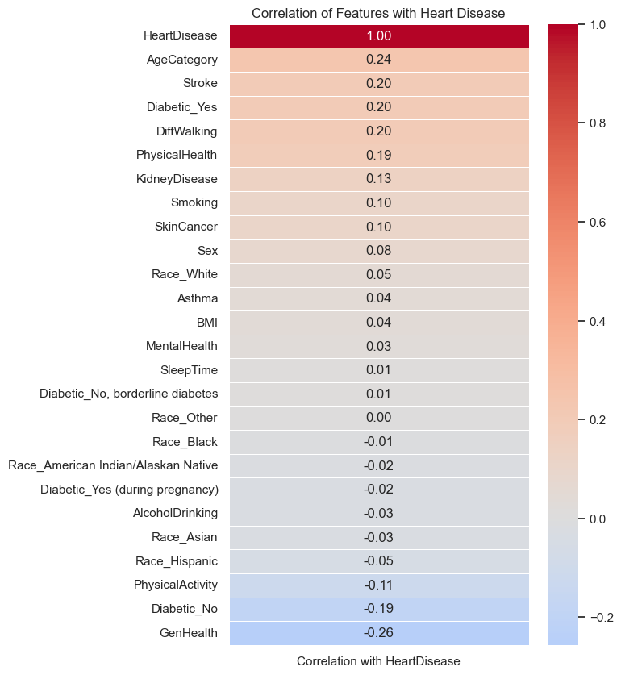

```python
corr = df_encoded.corr(numeric_only=True)['HeartDisease'] \
                 .sort_values(ascending=False)

# Display correlation table
corr_df = corr.to_frame(name='Correlation with HeartDisease')

plt.figure(figsize=(6, 10))

sns.heatmap(
    corr_df,
    annot=True,
    cmap='coolwarm',
    center=0,
    fmt=".2f",
    linewidths=0.5
)

plt.title("Correlation of Features with Heart Disease")
plt.show()
```

### Correlation Summary (Short)

The heatmap shows the **Pearson correlation (r)** between each feature and **HeartDisease**.

#### Strongest Positive Correlations (Higher Risk)

- **AgeCategory (0.24)** – risk increases with age
- **Diabetic_Yes (0.20)** – diabetes increases risk
- **Stroke (0.20)** – prior stroke is a major risk factor
- **DiffWalking (0.20)** – mobility issues reflect poorer health

#### Notes

- Most features show **weak to moderate** linear correlations
- Near-zero correlation ≠ unimportant (effects may be non-linear or multivariate)
- Correlation does **not imply causation**
- We can remote features which has persons r less than 0.03 to improve the model

```python
# Compute correlation with target
corr_with_target = df_encoded.corr(numeric_only=True)['HeartDisease']

# Set threshold
threshold = 0.03

# Identify unimportant features
low_corr_features = corr_with_target[
    corr_with_target.abs() < threshold
].index.tolist()

# Remove target if present
low_corr_features = [c for c in low_corr_features if c != 'HeartDisease']

# Drop low-importance features
df_reduced = df_encoded.drop(columns=low_corr_features)

print("Removed features:")
print(low_corr_features)

print("\nRemaining features:")
print(df_reduced.columns.tolist())
```

```
Removed features:
['AlcoholDrinking', 'MentalHealth', 'SleepTime', 'Race_American Indian/Alaskan Native', 'Race_Asian', 'Race_Black', 'Race_Other', 'Diabetic_No, borderline diabetes', 'Diabetic_Yes (during pregnancy)']

Remaining features:
['HeartDisease', 'BMI', 'Smoking', 'Stroke', 'PhysicalHealth', 'DiffWalking', 'Sex', 'AgeCategory', 'PhysicalActivity', 'GenHealth', 'Asthma', 'KidneyDisease', 'SkinCancer', 'Race_Hispanic', 'Race_White', 'Diabetic_No', 'Diabetic_Yes']
```

### Split the data by Statify=y with ratio 80:20

```python
# Target
y = df_reduced['HeartDisease']

# Features (drop target)
X = df_reduced.drop(columns=['HeartDisease'])

# Stratified split
X_train, X_test, y_train, y_test = train_test_split(
    X,
    y,
    test_size=0.2,
    stratify=y,
    random_state=42
)

# Verify class distribution
print("Train distribution:")
print(y_train.value_counts(normalize=True))

print("\nTest distribution:")
print(y_test.value_counts(normalize=True))
```

```
Train distribution:
HeartDisease
0    0.901195
1    0.098805
Name: proportion, dtype: float64

Test distribution:
HeartDisease
0    0.901135
1    0.098865
Name: proportion, dtype: float64
```

## 1️⃣3️⃣ Data Leakage Awareness

### Correct order

1. **Splitting**
2. **Encoding**
3. **Scaling**

### Orders that cause data leakage

- Encoding **before** splitting
- Scaling **before** splitting

**Why**

- Encoder/scaler learns statistics from **test data**
- Model indirectly “sees” unseen data

### Why leakage is especially dangerous in healthcare ML

- Inflates accuracy and AUC
- Creates false clinical confidence
- Can lead to unsafe medical decisions

## 1️⃣4️⃣ Scaling Strategy

### Chosen scaler: **RobustScaler**

**Justification**

- **Outliers**
  - BMI and health-day counts contain extreme values
  - RobustScaler uses median and IQR → resistant to outliers
- **Medical meaning**
  - Preserves relative differences without forcing min/max bounds
  - Avoids distortion from abnormal clinical cases
- **Model sensitivity**
  - Suitable for linear, distance-based, and neural models
  - More stable than StandardScaler with skewed health data

### Should encoded categorical features be scaled?

**No, Why:**

- Scaling destroys categorical meaning
- Breaks ordinal relationships
- Encoded values are labels, not measurements

```python
from sklearn.preprocessing import RobustScaler

# Numerical features to scale
num_cols = ['BMI', 'PhysicalHealth'] # SleepTime and MentalHealth removed

# Initialize scaler
scaler = RobustScaler()

# Fit ONLY on training data
X_train[num_cols] = scaler.fit_transform(X_train[num_cols])

# Transform test data
X_test[num_cols] = scaler.transform(X_test[num_cols])

# Check result
X_train[num_cols].describe()
```

|  | BMI | PhysicalHealth |
| --- | --- | --- |
| count | 13390.000000 | 13390.000000 |
| mean | 0.135180 | 1.948954 |
| std | 0.913562 | 4.220356 |
| min | -2.146269 | 0.000000 |
| 25% | -0.449254 | 0.000000 |
| 50% | 0.000000 | 0.000000 |
| 75% | 0.550746 | 1.000000 |
| max | 8.298507 | 15.000000 |

## 1️⃣5️⃣ Final Pipeline Construction

### Chosen approach: **Pipeline**

**Justification**

**Why not others**

- **Manual preprocessing:** error-prone, easy to leak data
- **ColumnTransformer alone:** handles columns, but Pipeline controls the full workflow

**Rule**

> In healthcare ML, always use a **Pipeline** to guarantee safety and validity.

```python
from sklearn.pipeline import Pipeline
from sklearn.preprocessing import RobustScaler
from sklearn.linear_model import LogisticRegression

X = df_reduced.drop(columns=['HeartDisease'])
y = df_reduced['HeartDisease']

pipeline = Pipeline(steps=[
    ('model', LogisticRegression(max_iter=1000))
])

pipeline.fit(X_train, y_train)

print("Train score:", pipeline.score(X_train, y_train))
print("Test score:", pipeline.score(X_test, y_test))
```

```
Train score: 0.9023898431665422
Test score: 0.9050179211469535
```

# 🫀 Heart Disease Prediction Using Logistic Regression

## 1. Problem Overview

The objective of this project is to predict whether an individual has **heart disease** based on health, lifestyle, and demographic features.

This is a **binary classification problem**:

- **0** → No heart disease
- **1** → Heart disease

## 2. Dataset Description

### Feature Types

**Numerical features**

- BMI
- PhysicalHealth
- ~MentalHealth~ (removed)
- ~SleepTime~ (removed)

**Categorical / binary features (already encoded)**

**Target variable**

- HeartDisease

## 3. Data Splitting Strategy

The data was split into:

- **80% Training set**
- **20% Testing set**

A **stratified split** was applied to preserve the original distribution of heart disease cases in both training and testing datasets.

This ensures a fair and reliable evaluation of model performance.

## 4. Model Selection

We used **Logistic Regression**, a widely used and interpretable algorithm for binary classification problems.

### Why Logistic Regression?

- Suitable for binary outcomes
- Computationally efficient
- Produces probabilistic outputs
- Commonly used in healthcare risk prediction

## 5. Preprocessing and Pipeline

Since all categorical features were **already encoded**, no additional encoding was applied.

## 6. Model Performance

The trained model achieved the following accuracy scores: Train score: 0.9023898431665422 Test score: 0.9050179211469535

- **Training Accuracy:** 90.24%
- **Testing Accuracy:** 90.50%

## 7. Performance Interpretation

The close similarity between training and testing accuracy indicates:

## 8. Practical Implications

This model can be used as a **baseline clinical decision-support tool**, helping to identify individuals at higher risk of heart disease.

Due to its interpretability, Logistic Regression allows for transparent analysis of how different health factors influence predictions.

## 9. Future Improvements

Possible extensions of this work include:

- Evaluating **ROC–AUC** and **confusion matrix**
- Handling class imbalance using `class_weight='balanced'`
- Analyzing feature importance using model coefficients
- Trying more advanced models (Random Forest, XGBoost)
- Hyperparameter tuning with GridSearchCV